# Homework_6

Anh Khoa Vo

November 9, 2017

# Question 1: StringR in data science

# 14.2.5

1. The difference between paste() and paste0() lies on the “sep” argument of the function. sep is used to separate every term in the vector. By default, paste() will separate each elemenents in the string with a space, whereas paste0() link string without spaces. For example:

```r
My_name <- c("A", "n", "h")
My_name_changed <- paste(My_name)
My_name_changed
```

```
## [1] "A" "n" "h"
```

```r
My_name2 <- paste0(My_name)
My_name2
```

```
## [1] "A" "n" "h"
```

Paste0() is equivalent to str_c(), and paste() is equivalent to str_c(, sep = “”)

2. The sep argument in str_c() will insert strings between input vectors, but the collapse argument in str_c() will concatenate input vectors into a single string. For example,

```r
library(stringr)
My_Full_Name <- c("A", "n", "h", "K", "h", "o", "a", "V", "o")
str_c(My_Full_Name, sep = "")
```

```
## [1] "A" "n" "h" "K" "h" "o" "a" "V" "o"
```

```r
str_c(My_Full_Name, collapse = "")
```

```
## [1] "AnhKhoaVo"
```

```r
df <- c("Is R really fun")
str_length(df)
```

```
## [1] 15
```

```r
str_sub(df, 7, 7)
```

```
## [1] "e"
```

4. str_wrap() is used to edit the existing whitespace to wrap a paragraphs in a way that each line has similar lengths to each other. You might use this function in graph, such as ggplot that has a long varibles’ names in the Axis.
5. str_trim() is used to remove any leading and trailing whitespace. The opposite of str_trim() is str_pad(), which adds extra whitespace on the left, right, or both to a string.
6. Write function:

```r
library(stringr)
Vector_string <- function(x) {
  l <- length(x)
  if (l == 0) return("")
  if (l == 1) return(x)
  if (l == 2) return(str_c(x, collapse = " and "))
  if (l >= 3){
    n <- x[l]
    k <- c("and", n)
    x[l] <- str_c(k, collapse = " ")
    return(str_c(x, collapse = ", "))
  }
}
o <- c("a", "b", "c")
h <- Vector_string(o)
h
```

```
## [1] "a, b, and c"
```

# 14.3.1.1

```r
library(stringr)
l = "\"'\\"
writeLines(l)
```

```
## "'\
```

```r
str_view(l, "\\\"'\\\\")
```

[interactive chart not shown]

# 14.3.2.1

```r
k = "IsRreally$^$FUNNNNNNNMAYBE"
str_view(k, "\\$\\^\\$")
```

[interactive chart not shown]

# 14.3.3.1

```r
wordss <- c("color", "colour")
str_view(wordss, "ou", match = T)
```

[interactive chart not shown]

# 14.3.4.1

1. {1}, {1,}, {0,}

# 14.3.5.1

```r
wordsss <- c("ana", "anh", "decide", "table", "degree", "eleven", "one", "two")
str_view(wordsss, "^(.).*\\1$", match = T)
```

[interactive chart not shown]

```r
str_view(wordsss, "(..).*\\1", match = T)
```

[interactive chart not shown]

```r
str_view(wordsss, "(.).*\\1.*\\1", match = T)
```

[interactive chart not shown]

# 14.4.2

```r
str_view(words, "^x|x$", match = T)
```

[interactive chart not shown]

```r
start_x = str_detect(words, "^x")
end_x = str_detect(words, "x$")
words[start_x | end_x]
```

```
## [1] "box" "sex" "six" "tax"
```

```r
str_view(words, "^[aeuio].*[^aeuio]$", match = T)
```

[interactive chart not shown]

```r
start_vowel = str_detect(words, "^[aeuio]")
end_consonant = str_detect(words, "[^aeuio]$")
words[start_vowel & end_consonant]
```

```
##   [1] "about"       "accept"      "account"     "across"      "act"
##   [6] "actual"      "add"         "address"     "admit"       "affect"
##  [11] "afford"      "after"       "afternoon"   "again"       "against"
##  [16] "agent"       "air"         "all"         "allow"       "almost"
##  [21] "along"       "already"     "alright"     "although"    "always"
##  [26] "amount"      "and"         "another"     "answer"      "any"
##  [31] "apart"       "apparent"    "appear"      "apply"       "appoint"
##  [36] "approach"    "arm"         "around"      "art"         "as"
##  [41] "ask"         "at"          "attend"      "authority"   "away"
##  [46] "awful"       "each"        "early"       "east"        "easy"
##  [51] "eat"         "economy"     "effect"      "egg"         "eight"
##  [56] "either"      "elect"       "electric"    "eleven"      "employ"
##  [61] "end"         "english"     "enjoy"       "enough"      "enter"
##  [66] "environment" "equal"       "especial"    "even"        "evening"
##  [71] "ever"        "every"       "exact"       "except"      "exist"
##  [76] "expect"      "explain"     "express"     "identify"    "if"
##  [81] "important"   "in"          "indeed"      "individual"  "industry"
##  [86] "inform"      "instead"     "interest"    "invest"      "it"
##  [91] "item"        "obvious"     "occasion"    "odd"         "of"
##  [96] "off"         "offer"       "often"       "okay"        "old"
## [101] "on"          "only"        "open"        "opportunity" "or"
## [106] "order"       "original"    "other"       "ought"       "out"
## [111] "over"        "own"         "under"       "understand"  "union"
## [116] "unit"        "university"  "unless"      "until"       "up"
## [121] "upon"        "usual"
```

# 14.4.4.1

```r
contraction = str_subset(sentences, "[^ ]+\\'[^ .]+")
str_extract(contraction, "[^ ]+\\'[^ .]+")
```

```
##  [1] "It's"       "man's"      "don't"      "store's"    "workmen's"
##  [6] "Let's"      "sun's"      "child's"    "king's"     "It's"
## [11] "don't"      "queen's"    "don't"      "pirate's"   "neighbor's"
```

# 14.4.5.1

```r
K = "AnhKhoaVo//REALLY//enjoys/////R///right////now//cant/wait/to/die"
str_replace_all(K, "/", "\\\\")
```

```
## [1] "AnhKhoaVo\\\\REALLY\\\\enjoys\\\\\\\\\\R\\\\\\right\\\\\\\\now\\\\cant\\wait\\to\\die"
```

# 14.4.6.1

```r
froots = "apples, pears, and bananas"
str_split(froots, ", and |, ")
```

```
## [[1]]
## [1] "apples"  "pears"   "bananas"
```

# 14.5.1

```r
dying = c("I\\", "am\\", "seriously\\", "dying\\", "right\\", "now\\", "Icantdeal\\")
str_view(dying, regex("\\\\"))
```

[interactive chart not shown]

```r
str_view(dying, fixed("\\"))
```

[interactive chart not shown]

#14.7 1. Count the number of words. stri_count_words 2. Find duplicated strings. stri_duplicated 3. Generate random text. stri_rand_strings

# Question 2: Write own function

```r
library("gapminder")
fit.model <- function(dat) {
  base_model <- lm(lifeExp ~ year + I(year^2) + pop, dat)
  full_model <- lm(lifeExp ~ year + I(year^2) + pop + gdpPercap + factor(continent), dat)
  x <- anova(base_model, full_model)
  return(list(x,base_model, full_model))
}

f <- fit.model(gapminder)
f
```

```
## [[1]]
## Analysis of Variance Table
##
## Model 1: lifeExp ~ year + I(year^2) + pop
## Model 2: lifeExp ~ year + I(year^2) + pop + gdpPercap + factor(continent)
##   Res.Df    RSS Df Sum of Sq      F    Pr(>F)
## 1   1700 228545
## 2   1695  78816  5    149729 644.01 < 2.2e-16 ***
## ---
## Signif. codes:  0 '***' 0.001 '**' 0.01 '*' 0.05 '.' 0.1 ' ' 1
##
## [[2]]
##
## Call:
## lm(formula = lifeExp ~ year + I(year^2) + pop, data = dat)
##
## Coefficients:
## (Intercept)         year    I(year^2)          pop
##  -1.425e+04    1.414e+01   -3.490e-03    3.610e-09
##
##
## [[3]]
##
## Call:
## lm(formula = lifeExp ~ year + I(year^2) + pop + gdpPercap + factor(continent),
##     data = dat)
##
## Coefficients:
##               (Intercept)                       year
##                -1.465e+04                  1.456e+01
##                 I(year^2)                        pop
##                -3.606e-03                  1.850e-09
##                 gdpPercap  factor(continent)Americas
##                 3.000e-04                  1.428e+01
##     factor(continent)Asia    factor(continent)Europe
##                 9.363e+00                  1.934e+01
##  factor(continent)Oceania
##                 2.053e+01
```

```r
library("dplyr")
library("tidyverse")
```

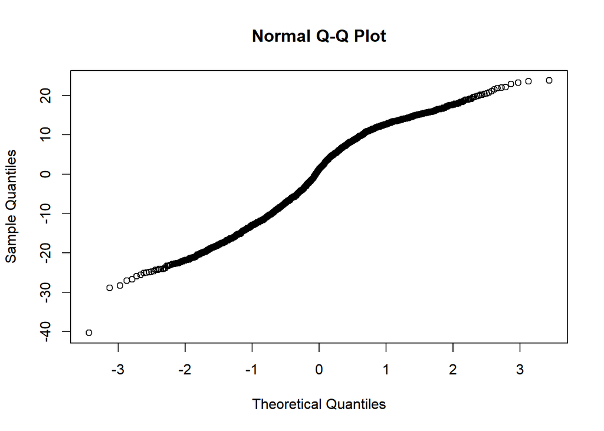

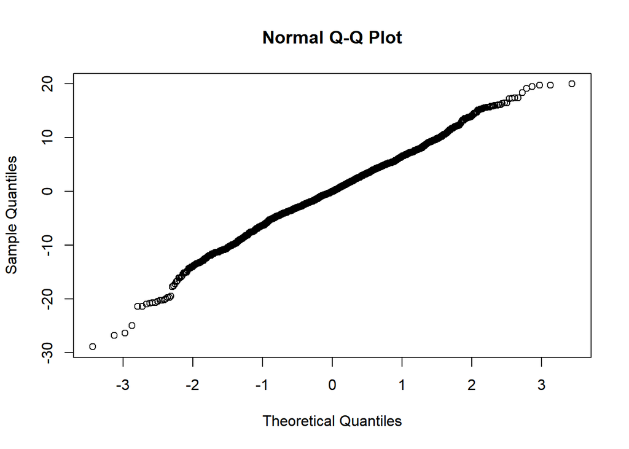

```r
resid.model <- function(fit) {
  z <- qqnorm(resid(fit[[2]]))
  t <- qqnorm(resid(fit[[3]]))
  df1 <- data.frame(x = z$x, y = z$y, lab = "Residuals Base")
  df2 <- data.frame(x = t$x, y = t$y, lab = "Residuals Full")
  u <- dplyr::union(df1, df2)
  i <- arrange(u, lab)
  return(i)
}

g <- resid.model(f)
```

```r
g
```

```
##                  x             y            lab
## 1    -1.7979615660 -20.433141048 Residuals Base
## 2    -1.0118292158 -13.169173946 Residuals Base
## 3     0.4772052649   8.250753631 Residuals Base
## 4     0.0448813556   2.023087857 Residuals Base
## 5    -0.1991618380  -3.035057694 Residuals Base
## 6    -1.0493564707 -13.646464459 Residuals Base
## 7    -0.4106379553  -6.101563575 Residuals Base
## 8    -2.0992130735 -22.595398209 Residuals Base
## 9    -0.3599337015  -5.633702118 Residuals Base
## 10    1.5888724072  15.538257253 Residuals Base
## 11    0.8849683368  12.086740658 Residuals Base
## 12   -1.0316629343 -13.459426631 Residuals Base
## 13   -1.0804775527 -13.854113406 Residuals Base
## 14   -0.4218670446  -6.188934542 Residuals Base
```

[output cut: 3394 more lines]